# STAT115 Homework 1

January 28, 2020

# Part 0: Odyssey Signup

Please fill out the Odyssey survey on Canvas so we can create an account for you.

# Part I: Introduction to R

## Problem 1: Installation

**Please install the following R/Bioconductor packages**

```r
if (!requireNamespace("BiocManager", quietly = TRUE))
    install.packages("BiocManager")
BiocManager::install()
BiocManager::install("sva")

install.packages(c("ggplot2", "dplyr", "tidyr", "HistData", "mvtnorm",
                   "reticulate"))
```

Please run this command to see if Bioconductor can work fine.

```r
# please knit with this command echoed.
BiocManager::valid()
```

```
## Warning: 4 packages out-of-date; 0 packages too new
```

```r
# these packages are needed for HW2
# affy and affyPLM are needed to read the microarray data and run RMA
library(sva) # for batch effect correction. Contains ComBat and sva.
library(ggplot2) # for plotting
library(dplyr) # for data manipulation
library(reticulate) # needed to run python in Rstudio
# these next two are not essential to this course
library(mvtnorm) # need this to simulate data from multivariate normal
library(HistData) # need this for data
```

When we grade, we should download their Rmd and knit it ourselves. They should have points removed if their document does not knit. On this HW, we will not take off points, but will warn them for next time.

If they have hard-coded file names, we will warn them on this as well.

## Problem 2: Getting help

You can use the `mean()` function to compute the mean of a vector like so:

```r
x1 <- c(1:10, 50)
mean(x1)
```

```
## [1] 9.545455
```

However, this does not work if the vector contains NAs:

```r
x1_na <- c(1:10, 50, NA)
mean(x1_na)
```

```
## [1] NA
```

**Please use R documentation to find the mean after excluding NA’s (hint: `?mean`)**

```r
# your code here
mean(x1_na, na.rm=TRUE)
```

```
## [1] 9.545455
```

# Part II: Data Manipulation

## Problem 3: Basic Selection

In this question, we will practice data manipulation using a dataset collected by Francis Galton in 1886 on the heights of parents and their children. This is a very famous dataset, and Galton used it to come up with regression and correlation.

The data is available as `GaltonFamilies` in the `HistData` package. Here, we load the data and show the first few rows. To find out more information about the dataset, use `?GaltonFamilies`.

```r
data(GaltonFamilies)
head(GaltonFamilies)
```

```
##   family father mother midparentHeight children childNum gender childHeight
## 1    001   78.5   67.0           75.43        4        1   male        73.2
## 2    001   78.5   67.0           75.43        4        2 female        69.2
## 3    001   78.5   67.0           75.43        4        3 female        69.0
## 4    001   78.5   67.0           75.43        4        4 female        69.0
## 5    002   75.5   66.5           73.66        4        1   male        73.5
## 6    002   75.5   66.5           73.66        4        2   male        72.5
```

1. **Please report the height of the 10th child in the dataset.**

```r
# your code here
GaltonFamilies[10,'childHeight']
```

```
## [1] 68
```

2. **What is the breakdown of male and female children in the dataset?**

```r
# your code here
GaltonFamilies %>%
  group_by(gender) %>%
  summarize(number = n())
```

```
## # A tibble: 2 x 2
##   gender number
##   <fct>   <int>
## 1 female    453
## 2 male      481
```

3. **How many observations are in Galton’s dataset? Please answer this question without consulting the R help.**

```r
# your code here
nrow(GaltonFamilies)
```

```
## [1] 934
```

4. **What is the mean height for the 1st child in each family?**

```r
# your code here
mean(GaltonFamilies[GaltonFamilies["childNum"]==1, "childHeight"])
```

```
## [1] 69.82098
```

5. **Create a table showing the mean height for male and female children.**

```r
# your code here
GaltonFamilies %>%
  group_by(gender) %>%
  summarize(avgHeight = mean(childHeight))
```

```
## # A tibble: 2 x 2
##   gender avgHeight
##   <fct>      <dbl>
## 1 female      64.1
## 2 male        69.2
```

6. **What was the average number of children each family had?**

```r
# your code here
GaltonFamilies %>%
  group_by(family) %>%
  summarize(children = mean(children)) %>%
  summarize(avgChildren = mean(children, na.rm = TRUE))
```

```
## # A tibble: 1 x 1
##   avgChildren
##         <dbl>
## 1        4.56
```

7. **Convert the children’s heights from inches to centimeters and store it in a column called `childHeight_cm` in the `GaltonFamilies` dataset. Show the first few rows of this dataset.**

```r
# your code here
GaltonFamilies <- mutate(GaltonFamilies,
  childHeight_cm = childHeight * 2.54
)
head(GaltonFamilies)
```

```
##   family father mother midparentHeight children childNum gender childHeight
## 1    001   78.5   67.0           75.43        4        1   male        73.2
## 2    001   78.5   67.0           75.43        4        2 female        69.2
## 3    001   78.5   67.0           75.43        4        3 female        69.0
## 4    001   78.5   67.0           75.43        4        4 female        69.0
## 5    002   75.5   66.5           73.66        4        1   male        73.5
## 6    002   75.5   66.5           73.66        4        2   male        72.5
##   childHeight_cm
## 1        185.928
## 2        175.768
## 3        175.260
## 4        175.260
## 5        186.690
## 6        184.150
```

## Problem 4: Spurious Correlation

```r
# set seed for reproducibility
set.seed(1234)
N <- 25
ngroups <- 100000
sim_data <- data.frame(group = rep(1:ngroups, each = N),
                       X = rnorm(N * ngroups),
                       Y = rnorm(N * ngroups))
```

In the code above, we generate 10^{5} groups of 25 observations each. In each group, we have X and Y, where X and Y are independent normally distributed data and have 0 correlation.

1. **Find the correlation between X and Y for each group, and display the highest correlations.**

Hint: since the data is quite large and your code might take a few moments to run, you can test your code on a subset of the data first (e.g. you can take the first 100 groups like so):

```r
sim_data_sub <- sim_data %>% filter(group <= 100)
```

In general, this is good practice whenever you have a large dataset: If you are writing new code and it takes a while to run on the whole dataset, get it to work on a subset first. By running on a subset, you can iterate faster.

However, please do run your final code on the whole dataset.

```r
# your code here
sim_corr <- sim_data %>%
  group_by(group) %>%
  summarize(correlation = cor(X, Y)) %>%
  arrange(desc(correlation))

head(sim_corr)
```

```
## # A tibble: 6 x 2
##   group correlation
##   <int>       <dbl>
## 1 99655       0.801
## 2 98068       0.782
## 3 66510       0.746
## 4 46164       0.719
## 5 30063       0.719
## 6 63287       0.715
```

2. **The highest correlation is around 0.8. Can you explain why we see such a high correlation when X and Y are supposed to be independent and thus uncorrelated?**

X and Y are supposed to be independent, but that is when we consider the entire dataset as a whole. When we are randomly creating groups chosen from the dataset, this randomness can lead to the two variables creating what seems to be a causal or correlated relationship, but really only results from coincidental similar movement. This spurious correlation is often caused by small sample sizes, as well as the fact that we are choosing as many as 100000 random groups, which can increase variability in random correlation.

# Part III: Plotting

## Problem 5

**Show a plot of the data for the group that had the highest correlation you found in Problem 4.**

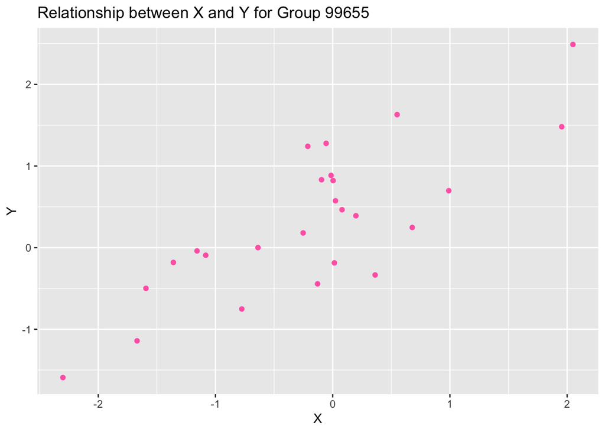

```r
# your code here
sim_data %>%
  filter(group == sim_corr[[1,1]]) %>%
  ggplot(aes(x = X, y = Y)) +
  geom_point(color = "hotpink") +
  ggtitle(paste0("Relationship between X and Y for Group ", sim_corr[[1,1]])) +
  xlab("X") +
  ylab("Y")
```

Grading: 1pt.

## Problem 6

We generate some sample data below. The data is numeric, and has 3 columns: X, Y, Z.

```r
N <- 100
Sigma <- matrix(c(1, 0.75, 0.75, 1), nrow = 2, ncol = 2) * 1.5
means <- list(c(11, 3), c(9, 5), c(7, 7), c(5, 9), c(3, 11))
dat <- lapply(means, function(mu)
  rmvnorm(N, mu, Sigma))
dat <- as.data.frame(Reduce(rbind, dat)) %>%
  mutate(Z = as.character(rep(seq_along(means), each = N)))
names(dat) <- c("X", "Y", "Z")
```

1. **Compute the overall correlation between X and Y.**

```r
# your code here
cor(dat["X"], dat["Y"])
```

```
##            Y
## X -0.7362015
```

2. **Make a plot showing the relationship between X and Y. Comment on the correlation that you see.**

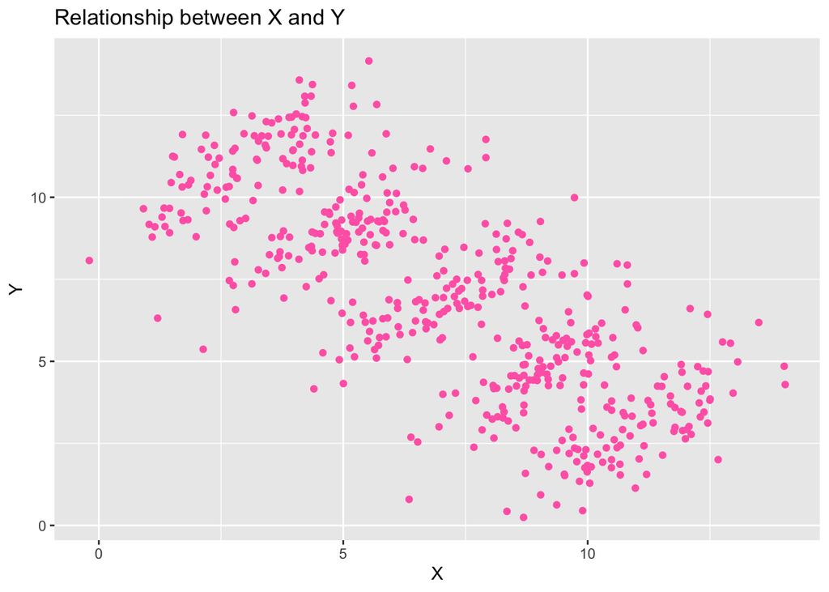

```r
# your code here
dat %>%
  ggplot(aes(x = X, y = Y)) +
  geom_point(color = "hotpink") +
  ggtitle("Relationship between X and Y") +
  xlab("X") +
  ylab("Y")
```

It appears that there is a relatively significant negative correlation between X and Y—that is, as X increases, Y tends to decrease in a relatively linear fashion. However, the range and variability around this linear decrease is also quite wide.

3. **Compute the correlations between X and Y for each level of Z.**

```r
# your code here
dat %>%
  group_by(Z) %>%
  summarize(correlation = cor(X, Y))
```

```
## # A tibble: 5 x 2
##   Z     correlation
##   <chr>       <dbl>
## 1 1           0.743
## 2 2           0.756
## 3 3           0.772
## 4 4           0.785
## 5 5           0.730
```

4. **Make a plot showing the relationship between X and Y, but this time, color the points using the value of Z. Comment on the result, especially any differences between this plot and the previous plot.**

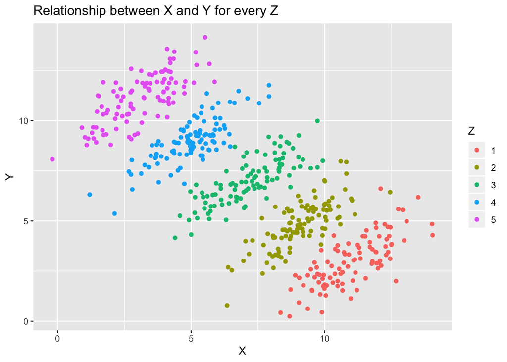

```r
# your code here
dat %>%
  ggplot(aes(x = X, y = Y, color = Z)) +
  geom_point() +
  ggtitle("Relationship between X and Y for every Z") +
  xlab("X") +
  ylab("Y")
```

Interestingly, plotting based on Z groups gives a very different result from our previous plot. In our previous plot, we inferred a correlation between X and Y that is solidly negative, and reflects a decrease in Y as X increases. In this plot, however, we can see that within each Z group, there is actually a solidly positive correlation. That is, when Z remains the same, as X increases, Y increases. This positive correlation was obscured when we no longer consider the Z value, turning into a negative correlation. This is reflective of our previous problem on spurious correlation, where correlation over the entire dataset may be different from the correlation for smaller groups selected from the larger dataset.

# Part IV: Bash practices

## Problem 7: Bash practices on Odyssey

Please answer the following question using bash commands and include those in your answer. Data are available at `/n/stat115/2020/HW1/public_MC3.maf`

Mutation Annotation Format ([MAF](https://docs.gdc.cancer.gov/Data/File_Formats/MAF_Format/)) is a tab-delimited text file with aggregated mutation information. `public_MC3.maf` is a curated list of [somatic mutation](https://www.britannica.com/science/somatic-mutation) occured in many patients. Since a complete MAF file contains far more information than we need, in this problem we will focus on part of it.

```
Chromosome  Start_Position  Hugo_Symbol Variant_Classification
10  123810032   TACC2   Missense_Mutation
10  133967449   JAKMIP3 Silent
11  124489539   PANX3   Missense_Mutation
11  47380512    SPI1    Missense_Mutation
11  89868837    NAALAD2 Missense_Mutation
11  92570936    FAT3    Silent
12  107371855   MTERFD3 Missense_Mutation
12  108012011   BTBD11  Missense_Mutation
12  117768962   NOS1    5'Flank
```

In `/n/stats115/2020/HW1/MC3/public_MC3.maf`, `Chromosome` and `Start_Position` together specifies the genomics location where a location has happened. `Hogo_symbol` is the overlapping gene of that location, and `Variant_Classification` specifies how it influences downstream biological processes, e.g. transcription and translation. We are interested to find out recurrent mutations with biological significance.

Hint: In this exercise you might need to use `cut` and `sort` command. Please try `man cut` and `man sort` to understand how it works. You might also benefit if you use pipes `|`.

1. How many lines are there in this file? How many times “KRAS” gene has appeared?

```bash
# your bash command
FILE_NAME="/n/stat115/2020/HW1/public_MC3.maf"
cat "$FILE_NAME" | wc -l

grep -c "KRAS" "$FILE_NAME"
```

3600964 lines  
921 times “KRAS” gene appeared

2. How many unique `Variant_Classification` are there in the MAF? Please count occurrence of each type and sort them. Which one is the most frequent?

```bash
# your bash command
FILE_NAME="/n/stat115/2020/HW1/public_MC3.maf"
cut -f 4 "$FILE_NAME" | sort -u | wc -l

cut -f 4 "$FILE_NAME" | sort | uniq -c | sort -nr
```

17 different variant classifications

1921979 Missense_Mutation  
782687 Silent  
282636 3’UTR  
157232 Nonsense_Mutation  
108104 Intron  
87013 Frame_Shift_Del  
81323 5’UTR  
50617 Splice_Site  
49540 RNA  
27128 Frame_Shift_Ins  
21060 3’Flank  
15726 5’Flank  
10254 In_Frame_Del  
2723 Translation_Start_Site  
2042 Nonstop_Mutation  
899 In_Frame_Ins  
1 Variant_Classification

Missense mutations are the most frequent kind of variant classification.

3. What are the top FIVE most frequent genes? Please provide the bash command and equivalent Python command. If you are a PI looking for a gene to investigate (you need to find a gene with potentially better biological significance), which gene out of the top 5 would you choose? Why?

```bash
# your bash command
FILE_NAME="/n/stat115/2020/HW1/public_MC3.maf"
cut -f 3 "$FILE_NAME" | sort | uniq -c | sort -nr | head -5
```

Equivalent python command:

```python
# your python command
with open('/n/stat115/2020/HW1/public_MC3.maf') as f:
    lines = [line.rstrip().split('\t')[2] for line in f]

from collections import Counter
cc = Counter(lines)

for gene, count in cc.most_common(5):
    print (gene, ":", count)
```

Your text answer:

TTN : 15171  
MUC16 : 6875  
TP53 : 4601  
CSMD3 : 3198  
SYNE1 : 3102

I would likely pick TTN. TTN has the most variant classifications in our data, which suggests that changes in TTN would be relatively more biologically significant since it is more likely to mutate.

4. Write a bash program that determines whether a user-input year ([YYYY]) is a leap year or not (Definition: multiples of four with the exception of centennial years not divisible by 400). The user-input can be either positional or interactive.

```bash
# your bash command
echo -n "Enter year (yyyy) : "
read year

if [[ $((year % 400)) -eq 0 ]]
then
  echo "$year is a leap year."
elif [[ $((year % 100)) -eq 0 ]]
then
  echo "$year is not a leap year."
elif [[ $((year % 4)) -eq 0 ]]
then
  echo "$year is a leap year."
else
  echo "$year is not a leap year."
fi
```

# Part V. High throughput sequencing read mapping

We will give you a simple example to test high throughput sequencing alignment for RNA-seq data. Normally for paired-end sequencing data, each sample will have two separate FASTQ files, with line-by-line correspondence to the two reads from the same fragment. Read mapping could take a long time, so we have created just two FASTQ files of one RNA-seq sample with only 1M fragments (three 2 X 1M reads) for you to run STAR instead of the full data. The files are located at `/n/stat115/2020/HW1/loop/`.

```
loop
├── A_l.fastq
├── A_r.fastq
├── B_l.fastq
├── B_r.fastq
├── C_l.fastq
└── C_r.fastq
```

Please include the commands that you used to run BWA and STAR in your answers.

## Problem 8: BWA

1. Use BWA (Li & Durbin, Bioinformatics 2009) to map the reads to the Hg38 version of the reference genome, available on Odyssey at `/n/stat115/2020/HW1/bwa_hg38_index/hg38.fasta`.

In `/n/stat115/2020/HW1/loop`, you are provided with three `.fastq` files/ Write a for loop in bash to align the paired-end reads to the reference using BWA on a compute node. Use the PE alignment mode and generate the output in SAM format. Use SAMTools on the output to find out how many fragments are mappable and uniquely mappable. How many rows are in each output SAM files?

```bash
# please copy your bash script here

REF_FILE="/n/stat115/2020/HW1/bwa_hg38_index/hg38.fasta"
READ_FILE="/n/stat115/2020/HW1/loop"

module load bwa/0.7.15-fasrc02
module load samtools/1.5-fasrc02

# loop over the three
for f in A B C
do
    # align each end separately
    bwa aln $REF_FILE $READ_FILE/${f}_l.fastq > ${f}_l.sai
    bwa aln $REF_FILE $READ_FILE/${f}_r.fastq > ${f}_r.sai

    # stick everything in a SAM file
    bwa sampe $REF_FILE ${f}_l.sai ${f}_r.sai $READ_FILE/${f}_l.fastq $READ_FILE/${f}_r.fastq > ${f}-aln-pe.sam

    # count number of aligned reads, etc.
    samtools flagstat ${f}-aln-pe.sam

    # count number of uniquely mapped reads
    samtools view -h ${f}-aln-pe.sam | grep -v -e 'XA:Z:'  -e 'SA:Z:'| samtools view -F 0x900 -f 0x2 -q 5| wc -l
done
```

Please provide text answer here.

A: 1900632 mapped, unique: 1028780  
B: 1900322 mapped, unique: 1028085  
C: 1900666 mapped, unique: 1028016

There are 2000026 rows in each of the output SAM files.

2. Use slurm to submit the same BWA alignment jobs onto cluster for `A_r.fastq` and `A_l.fastq`. Please copy the content of your `sbatch` file here.

```bash
# please copy your sbatch file here

#!/bin/bash
#SBATCH -n 1 # Number of cores requested
#SBATCH -N 1 # Ensure that all cores are on one machine
#SBATCH -t 45 # Runtime in minutes
#SBATCH -p serial_requeue # Partition to submit to
#SBATCH --mem=6G # Memory in GB (see also --mem-per-cpu)
#SBATCH -o output_bwa.out # Standard out goes to this file
#SBATCH -e error_bwa.err # Standard err goes to this file

REF_FILE="/n/stat115/2020/HW1/bwa_hg38_index/hg38.fasta"
READ_FILE="/n/stat115/2020/HW1/loop"

module load bwa/0.7.15-fasrc02
module load samtools/1.5-fasrc02

bwa aln $REF_FILE $READ_FILE/A_l.fastq > A_l.sai
bwa aln $REF_FILE $READ_FILE/A_r.fastq > A_r.sai

bwa sampe $REF_FILE A_l.sai A_r.sai $READ_FILE/A_l.fastq $READ_FILE/A_r.fastq > A-aln-pe.sam
```

## Problem 9: STAR alignment

1. Use STAR (Dobin et al, Bioinformatics 2012) to map the reads to the reference genome, available on Odyssey at `/n/stat115/2020/HW1/STARIndex`. Use the paired-end alignment mode and generate the output in SAM format for `A_r.fastq` and `A_l.fastq` in `/n/stat115/2020/HW1/loop`. STAR should have a report.  
   How many fragments are mappable and how many are uniquely mappable?

```bash
# please copy your sbatch file here

#!/bin/bash
#SBATCH -n 1 # Number of cores requested
#SBATCH -N 1 # Ensure that all cores are on one machine
#SBATCH -t 30 # Runtime in minutes
#SBATCH -p serial_requeue # Partition to submit to
#SBATCH --mem=32G # Memory in GB (see also --mem-per-cpu)
#SBATCH -o output_star.out # Standard out goes to this file
#SBATCH -e error_star.err # Standard err goes to this file

STAR_FILE="/n/stat115/2020/HW1/STARIndex"
READ_FILE="/n/stat115/2020/HW1/loop"

module load STAR/2.6.0c-fasrc01

STAR --genomeDir $STAR_FILE \
--readFilesIn $READ_FILE/A_l.fastq $READ_FILE/A_r.fastq \
--runThreadN 1 --outFileNamePrefix output_star
```

Looking at the “output_starLog.final.out” file, we have 645280 uniquely mapped reads. The total number of mapped reads is 645280 uniquely mapped reads + 296011 reads mapped to multiple loci = 941291 reads.

2. If you are getting a different number of mappable fragments between BWA and STAR on the same data, why?

Please provide text answer here.

There are fewer mappable fragments from STAR, likely because BWA is not splice aware. Our genome likely has introns, which BWA does not know not to align the reference genome to the introns, resulting in more mappable fragments, which would be ignored and accounted for in STAR.

# Part VII: Dynamic programming with Python

## Problem 10 Dynamic Programming

Given a list of finite integer numbers: e.g. -2, 1, 7, -4, 5, 2, -3, -6, 4, 3, -8, -1, 6, -7, -9, -5. Write a python script to maximize the Z where Z is the sum of the numbers from location X to location Y on this list. Be aware, your algorithm should look at each number ONLY ONCE from left to right.

Hint: You can use dynamic programming to solve this problem with <20 lines of codes.

```python
# your bash command

numbers = [-2, 1, 7, -4, 5, 2, -3, -6, 4, 3, -8, -1, 6, -7, -9, -5]

maxsum = 0
maxstart = maxend = 0
newsum = 0

for end, n in enumerate(numbers):
    newsum += n

    if n > newsum:
        start = end
        newsum = n

    if newsum > maxsum:
        maxsum = newsum
        maxstart = start
        maxend = end

print("max Z value is from index", maxstart, "to", maxend, ":", maxsum)
```

```
## max Z value is from index 1 to 5 : 11
```

```python
print("subset:", numbers[maxstart:maxend+1])
```

```
## subset: [1, 7, -4, 5, 2]
```

The maximum Z value is 11, from index 1 to index 5: [1, 7, -4, 5, 2].